# K-Means Clustering Unsupervised Learning Algorithm

## Introduction

Expanded on in section 14.3.6, the K-Means Clustering algorithm classifies un-labeled data into clusters/groups based on the data's underlying patterns. Firstly, the algorithm will randomly assign each datapoint to one of $k$ clusters, for a given $k$. The mean of each cluster is computed, along with each datapoint's Euclidean distance to each cluster mean. The clusters are then reassigned to the cluster that minimizes the distance to the mean. This process is iterated until there are no changes in cluster assignments.

## Implementing the Algorithm

First, we implement the algorithm from scratch, and then compare the solution to scikit-learn's K-means function.

The first function we create provides a way to randomly generate normally distributed data. This function allows the specification of how many datapoints, the mean and standard devation of the normal distribution for different clusters, and the number of features or dimensions of the data.

```python
import numpy as np

def CreateRandomDataset(n_datapoints, mu, sigma, n_features = 2):

    dist = np.random.uniform(1, n_datapoints, len(mu))
    dist = np.round(dist * n_datapoints / dist.sum(), 0)
    if dist.sum() < n_datapoints:
        dist[-1] += n_datapoints - dist.sum()

    data = [np.random.normal(mu[i], sigma[i], size=(int(dist[i]), n_features)) for i in range(len(mu))]
    data = np.concatenate(data, axis = 0)

    return data
```

This function assigns the initial cluster assignment to each datapoint randomly.

```python
def AssignRandomClusters(n_datapoints, n_clusters):
    return np.random.choice(n_clusters, n_datapoints)
```

This function will take the data and cluster assignment as input and return the means for each cluster.

```python
def CalculateMeans(data, cluster, n_clusters):
    return np.array([data[np.where(cluster == i)].mean(axis = 0) for i in range(n_clusters)])
```

This function will take the data and the means of each cluster and return a $N \times k$ array, where $N$ is the number of datapoints, that stores the Euclidean distance of each datapoint to each cluster mean.

```python
def CalculateDistance(data, means):

    distances = []
    for i in range(means.shape[0]):
        distances.append(np.sqrt(((data - means[i])**2).sum(axis = 1)))
    distances = np.column_stack(distances)

    return distances
```

The below function will take the distance array and reassign the clusters so that each datapoint is assigned to the cluster that minimizes the distance to the mean.

```python
def AssignClosestCluster(distances, n_clusters):

    new_cluster = (distances == np.min(distances, axis = 1)[:, None]).argmax(1)
    n_dropped = n_clusters - max(new_cluster) - 1
    if n_dropped > 0:
        dropped = np.setdiff1d(np.arange(n_clusters), new_cluster)
        new_cluster = AssignRandomClusters(distances.shape[0], n_clusters)

    return new_cluster
```

Lastly, this driving function will take a data array as input along with a $k$ to return the cluster assignment.

```python
def KMeansClustering(data, n_clusters):

    n_datapoints = data.shape[0]
    cluster = AssignRandomClusters(n_datapoints, n_clusters)
    while 1:
        means = CalculateMeans(data, cluster, n_clusters)
        distances = CalculateDistance(data, means)
        new_cluster = AssignClosestCluster(distances, n_clusters)
        if (new_cluster == cluster).all():
            break
        else:
            cluster = new_cluster

    return cluster
```

We can test the model for $k = 3$ and $N = 10$ as shown below.

```python
n_clusters = 3
data = CreateRandomDataset(10, [0, 1, 2], [0.5, 0.25, 0.25])

cluster = KMeansClustering(data, n_clusters)
cluster
```

```
array([1, 1, 2, 2, 1, 2, 1, 2, 2, 0], dtype=int64)
```

```python
from sklearn.cluster import KMeans

kmeans = KMeans(n_clusters=n_clusters, random_state=0).fit(data)
kmeans.labels_
```

```
array([2, 2, 0, 0, 0, 0, 2, 0, 0, 1])
```

For $N=100$ and 2 features, we can visualize the 3 clusters on a scatter plot.

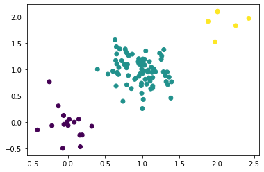

```python
n_clusters = 3
data = CreateRandomDataset(100, [0, 1, 2], [0.25, 0.25, 0.25])
cluster = KMeansClustering(data, n_clusters)

import matplotlib.pyplot as plt

plt.scatter(data[:,0], data[:,1], c=cluster)
plt.show()
```

We can also change the number of features/dimensions of the data. Below shows a $k=2$ clustering with three dimensional data.

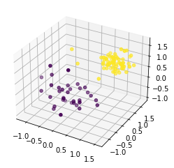

```python
n_clusters = 2
data = CreateRandomDataset(100, [0, 1], [0.5, 0.25], n_features = 3)
cluster = KMeansClustering(data, n_clusters)

fig = plt.figure()
ax = fig.add_subplot(projection='3d')
ax.scatter(data[:,0], data[:,1], data[:,2], c=cluster, marker='o')
plt.show()
```